# Internet Advertisements Challenge

V. Audigier & N. Niang

Bienvenue sur la page du challenge !

| **8** | **3** | **J - 142** |
| --- | --- | --- |
| soumissions | équipes | en cours |

Dernière mise à jour : `18 avr. 2025 09:44`

# News

**25 Mars 2025:**

Le challenge est ouvert !

Meilleur Score F1

| Classement | Equipe | Soumissions | Date | Score F1 |
| --- | --- | --- | --- | --- |
| 1. | C&C | 1 | 13/04/25 22:58 | 0.939 |
| 2. | ALANCE | 6 | 17/04/25 08:38 | 0.925 |
| 3. | baseline | 1 | 26/03/25 11:37 | 0.243 |
| 4. | Solo | 1 | 10/04/25 09:13 | 0.243 |

# Objectif

**Classification binaire** : On dispose d’un ensemble de 3279 images issues de pages internet. Cet ensemble représente de potentielles publicités apparaissant à l’écran. Les images sont caractérisées par des variables décrivant la géométrie de celle-ci (si disponible) ainsi que par l’occurrence de différents mots dans des composantes de l’image (mots-clés associés, lien URL, etc). La tâche consiste à prédire si une image est une publicité (`ad.`) ou non (`noad.`). Une description des données est disponible [ici](https://archive.ics.uci.edu/ml/machine-learning-databases/internet_ads/ad.DOCUMENTATION). Notez que nous ne possédons pas davantage d’informations sur ces données que celles que vous trouverez sur la page indiquée.

Après une analyse exploratoire des données, les équipes devront prédire si les images sont des publicités ou non sur un ensemble de données test.

# Déroulement du challenge

1. Envoyer un email à vincent.audigier@lecnam.net contenant les informations suivantes (**en intégralité**) :
   - nom de l’équipe et des participants
   - au moins une adresse email associée à un compte Dropbox
2. Vous recevrez une invitation à partager un dossier Dropbox portant le nom de votre équipe.

   Ce dossier aura été créé par l’enseignant, vous n’avez pas à le créer vous-même
3. Télécharger les données [ici](https://cnam-my.sharepoint.com/:f:/g/personal/vincent_audigier_lecnam_net/EsqxfW4vk2ZJpOUnEyaCkLEBNL6vRCPryx3yQ1YwOjSaxQ) (faire un clic-droit, puis ouvrir dans un nouvel onglet)
4. Effectuer l’analyse exploratoire
5. Soumettre vos prédictions sur le jeu test sous format csv dans le dossier Dropbox partagé (cf. point 2.).
- **Note** : Le nombre de soumissions n’est pas limité. Cependant, le calcul des scores n’est mis à jour que toutes les heures. Ce délai pourra parfois être plus long si l’ordinateur effectuant la mise à jour est éteint ou ne dispose plus d’une connexion internet.

**ATTENTION : VOTRE DOSSIER PARTAGE NE DOIT CONTENIR QUE VOS PREDICTIONS SUR LE JEU TEST** il ne doit en aucun cas contenir les données elles-mêmes, ou tout autre fichier de travail.

- **Date limite des soumissions** : dimanche 29 juin 2025 23:55 CEST pour la session 1 et dimanche 07 sept. 2025 23:55 CEST pour la session 2

# Description des données

Les données sont réparties en deux ensembles, apprentissage et test comme suit :

| Nom | Fichier | Description |  |
| --- | --- | --- | --- |
| Apprentissage | `data_train.rda` | `data.frame` avec `2459` lignes/images et `1559` colonnes/descripteurs |  |
| Test | `data_test.rda` | `data.frame` avec `820` lignes/images et `1558` colonnes/descripteurs |  |

Ces fichiers sont à importer dans R avec :

```r
load("data_train.rda")
load("data_test.rda")
```

La variable à prédire est la variable `outcome` dont la valeur est `ad.` ou `noad.` correspondant à une publicité ou non. Les valeurs d’apprentissage de cette variable sont fournies dans la dernière colonne de `data_train`. `data_test` ne contient pas cette colonne puisqu’elle doit être prédite.

Le jeu de données complet contient un nombre déséquilibré de publicités. Ces proportions sont identiques à la fois dans le jeu d’apprentissage et le jeu test.

```r
table(data_train$outcome)/nrow(data_train)
```

```
##
##       ad.     noad.
## 0.1398943 0.8601057
```

Pour la prédiction, on dispose de `1558` variables explicatives dont 3 variables quantitatives. Les autres sont toutes des variables qualitatives à deux modalités.

# Prédiction

Un classifieur est une fonction qui affecte une classe a l’ensemble des donnees test. Une telle fonction peut etre :

```r
predict_allad <- function(data_test, ...) {
  y_pred = rep("ad.", nrow(data_test))
  return(y_pred)
}
```

qui affecte affecte la même modalité (`ad.`) à tous les individus. Un tel classifieur n’utilise pas les donnees d’apprentissage. On obtient le resultat suivant

```r
y_pred <- predict_allad(data_test)
head(y_pred)
```

```
## [1] "ad." "ad." "ad." "ad." "ad." "ad."
```

Vous devez programmer un ou plusieurs classifieurs qui utilisent les données d’apprentissage pour améliorer les performances d’une telle décision.

# Critères de performance

Les performances de votre classifieur sont calculées en fonction des vraies réponses de l’ensemble test. Au vu de la problématique, on s’intéressera particulièrement à la détection des publicités (qualifiées de `positifs`), et non à celle des non-publicités (qualifiées de `négatifs`). Pour cette raison, on n’utilisera pas comme mesure de performances le taux de bon classement, car celui-ci mesure à la fois la capacité du classifieur à prédire correctement les positifs et les négatifs. Ainsi, la qualité du classifieur sera évaluée par le score F1. Celui-ci est une moyenne (harmonique) entre la *précision*, c’est-à-dire la part d’images correctement identifiées comme publicité (`vrais positifs`) parmi les images qui ont été identifiées (`vrais positifs et faux positifs`) et le *rappel*, c’est-à-dire la part des images correctement identifiées comme publicité parmi les images étant effectivement des publicités (`vrais positifs et faux négatifs`). Le score F1 est compris entre 0 et 1. La valeur 0 est atteinte si le classifieur ne détecte jamais les images comme étant des publicités et atteint la valeur de 1 si seuls les images étant des publicités sont détectées et ceci dans leur intégralité.

### Calcul du score F1

Le score F1 mesure la capacité du modèle à prédire correctement le caractère publicitaire d’une image. Il est mesuré par la fonction `F1_score`.

```
F1_score <-
function (y_pred, y_test)
{
    if (length(unique(y_pred)) == 1) {
        if (unique(y_pred) == "ad.") {
            VP <- table(y_test)["ad."]
            precision <- VP/length(y_pred)
            rappel <- 1
            F1 <- 2 * precision * rappel/(precision + rappel)
            return(F1)
        }
        else if (unique(y_pred) == "noad.") {
            return(0)
        }
    }
    confusion <- table(y_pred, y_test, deparse.level = 2)
    VP <- confusion["ad.", "ad."]
    if (VP == 0) {
        return(0)
    }
    FP <- confusion["ad.", "noad."]
    FN <- confusion["noad.", "ad."]
    precision <- VP/(VP + FP)
    rappel <- VP/(VP + FN)
    F1 <- 2 * precision * rappel/(precision + rappel)
    return(F1)
}
```

Le but est de construire un classifieur maximisant le score F1.

# Soumissions

Les soumissions se font sous forme de fichier texte portant l’extension `.csv`, que vous pouvez exporter avec la commande suivante :

```r
write(y_pred, file = "my_pred.csv")
```

Le fichier doit contenir `820` lignes contenant uniquement un des mots `ad.` ou `noad.`.

Tous les fichiers `.csv` placés dans votre répertoire Dropbox partagé seront automatiquement importés grâce à la fonction `read_pred`.

```r
read_pred <- function(file, n = 820) {
  y_pred <- scan(file, what = "character")
  if (length(y_pred) != n)
    stop("Le nombre de prédictions est incorrect")
  if (any(is.na(y_pred)))
    stop("Le vecteur de prédiction contient des valeurs manquantes (NA°")
  if(any(!(unique(y_pred)%in%c("ad.","noad.")))){
    stop(paste0("Le nom des modalités prédites doit être ad. ou noad. au lieu de ",paste(unique(y_pred),collapse = " ")))}
  if(length(unique(y_pred))==1){
    y_pred <- as.factor(y_pred)
    }else{
  y_pred <- factor(y_pred, levels = c("ad.", "noad."))}
  return(y_pred)
}
```

Utilisez cette fonction pour vérifier que votre fichier sera correctement importé.

Les erreurs de lecture lors de l’import sont affichées à la section Erreurs de lecture.

Une fois un fichier importé, son score est calculé et stocké. Vous pouvez effacer ou remplacer des soumissions, l’historique est conservé.

# Classement

Le classement ainsi que les scores affichés sont calculés sur seulement un tiers des données test. Le score final calculé sur toutes les données test sera révélé à la fin du challenge.

Seul le meilleur score par équipe parmi toutes les soumissions est retenu.

L’équipe `baseline` correspond au score du classifieur `predict_allad` qui tient lieu de référence à améliorer.

# Pour conclure

Il faut savoir bien distinguer les performances pures de votre prédicteur, votre classement par rapport aux autres équipes, et les attentes de l’UE lors de la rédaction du rapport final associé. En effet, au-delà de la qualité de votre prédiction, l’évaluation portera essentiellement sur la façon de construire ce prédicteur, notamment à partir de l’analyse exploratoire préalable, mais aussi sur la façon précise de le paramétrer et d’évaluer **par vous-même** ses performances. Le challenge, tel qu’il vous est proposé ici, n’est qu’un outil pour vous aider. Il vous permettra tout d’abord d’avoir une mesure objective des performances de vos prédicteurs. Un écart important entre les performances indiquées et celles que vous aviez pu calculer par vos propres moyens doit vous amener à vous interroger sur la méthodologie que vous auriez adoptée. Par ailleurs, votre classement vous permet de vous situer par rapport aux autres équipes. Des écarts importants doivent vous amener à vous interroger sur les prédicteurs construits. A nouveau, les évaluations que vous obtiendrez via vos soumissions ne se substituent en rien à l’évaluation que vous devez mener par vous-même et retranscrire dans votre rapport.

# Historique des soumissions

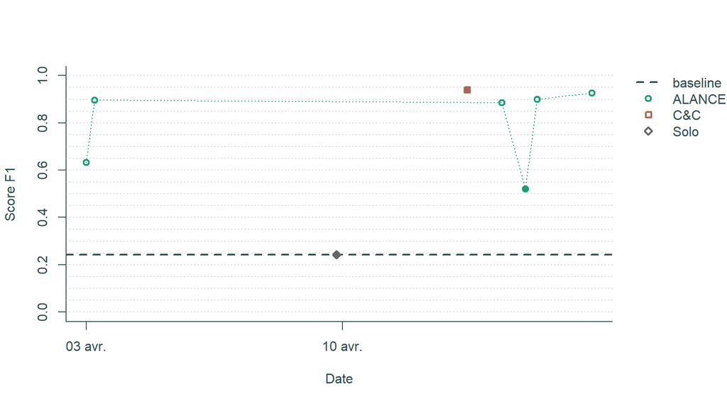

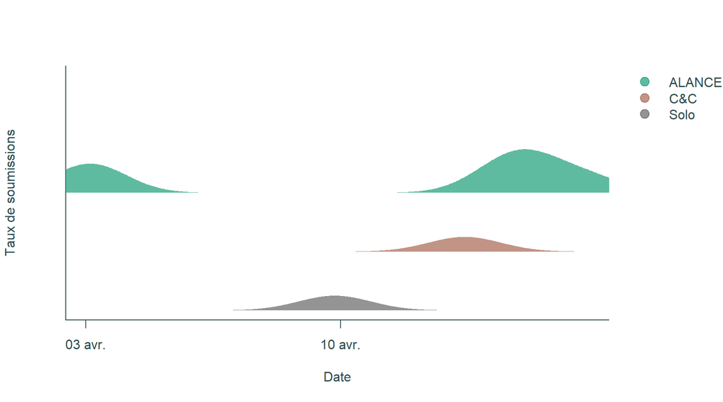

# Erreurs de lecture

| Equipe | Fichier | Message |
| --- | --- | --- |
| Solo | `my_pred.csv` | `Le nom des modalités prédites doit être ad. ou noad. au lieu de ad. nonad.` |

Développé avec [rchallenge](http://adrtod.github.io/rchallenge/).